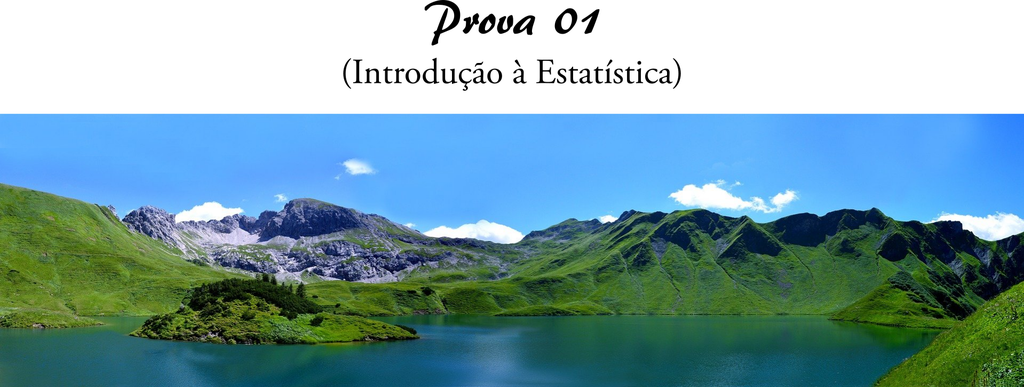

## Informações Relevantes

Usaremos algumas bases de dados reais para realização dessa prova. Por conta disso, o tempo de resolução será extendido, visto que algumas dessas bases possuem mais de 50 MB, o que pode ocasionar demora no *download*.

As bases de dados serão retiradas de nosso repositório do GitHub e do *site* brasil.io.

Faça o *download* dos seguintes conjuntos de dados:

1. [Salário de Magistrados](https://drive.google.com/u/0/uc?id=1FCdmXKf35dTtmnZQ1XhQPl7sF1MxX7WV&export=download);
2. [Cursos e notas de corte do PROUNI 2018](https://drive.google.com/u/0/uc?id=1lnqYHylEWT8cN6vPZ-NRR8KfFAPNq43r&export=download)
3. [Peixes do Rio Madeira](https://github.com/icaro-freire/dados_csv/blob/main/dados/csv/peixes_rio_madeira.csv)

O uso do *software* `R` é suficiente, mas não necessário. Ou seja, você pode usar qualquer outro *software* que estiver mais familiarizado, todavia, as dicas que serão dadas em algumas questões abaixo, serão voltadas para os usuários do `R`.

| ## Identificação |
| --- |
| **Aluno:** Luis Fernando dos Santos de Brito **Data:** (14/ 09/ 2021) |

## Questões (Soluções)

### carregandos os datasets

```r
dados_peixes <- read_csv("dados/peixes_rio_madeira.csv")
```

### I. Sobre o *dataset* `peixes_rio_madeira.csv`

**Questão 01.** Considerando a variável `ordem`, responda:

1. Faça uma distribuição de frequência da variável `ordem`, ordenando os valores numéricos de forma crescente.

```r
dados_peixes %>%
  count ( ordem ) %>%
  arrange ( n )
```

| ordem | n |
| --- | --- |
| Lepidosireniformes | 2 |
| Pleuronectiformes | 2 |
| Beloniformes | 5 |
| Não identificado | 17 |
| Myliobatiformes | 41 |
| Osteoglossiformes | 433 |
| Gymnotiformes | 693 |
| Acanthuriformes | 1602 |
| Cichliformes | 1947 |
| Clupeiformes | 2821 |

[output cut: 2 more lines]

2. Qual `ordem` de peixe foi a mais identificada? Quantas foram as observações?

*Resposta: Pela tabela a ordem de peixes mais identificados foi o characiformes com 64356 aparições.*

3. Quantos não foram identificados na variável `ordem`?

*Resposta: Não foram identificados na ordem 17 peixes.*

4. Faça um gráfico de barras para representar a variável ordem, nesse dataset.

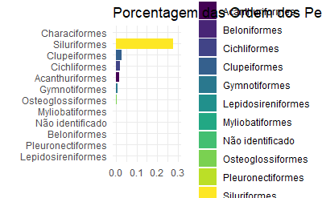

```r
dados_peixes %>%
  count(ordem) %>%
  mutate(prop = n / sum(n)) %>%
  ggplot() +
  aes(x = prop, y = fct_reorder(ordem, prop), fill = ordem) +
  geom_col() +
  scale_fill_viridis_d() +
  scale_x_continuous(
    limits = c(0, .3)
  ) +
  labs(
    title = "Porcentagem das Ordem dos Peixes",
    x = "",
    y = ""
  ) +
  theme_minimal()
```

**Questão 02.** Dentre os peixes que foram coletados da bacia do “Rio Guaporé”, após a seleção da `ordem` e do `peso_g`, bem como a eliminação dos elementos não identificados; deseja-se comparar qual das ordens é a mais **homogênea**, no que se refere ao seu peso. Para isso, é necessário comparar a variabilidade do `peso_g` em relação à média. Se a média é igual em cada ordem, usamos o **desvio padrão**. Todavia, se a média em cada ordem é diferente, precisamos padronizar essa medida; e, nesse caso, usamos o **coeficiente de variação** (cv), em porcentagem. Quanto menor a porcentagem do `cv`, mais homogênea é a distribuição do `peso_g`. Define-se:
$$\text{cv} = \frac{\text{desvio padrão}}{média} \cdot 100$$

```r
dados_peixes %>%
  select(bacia, ordem, peso_g)%>%
  filter(bacia == "Rio Guaporé")%>%
  group_by(ordem)%>%
  summarise(
    media_peso = mean(peso_g,na.rm = TRUE),
    desvio_peso = sd(peso_g,na.rm = TRUE),
    coeficiente_variacao_peso = ((desvio_peso/media_peso)*100)
  )
```

| ordem | media_peso | desvio_peso | coeficiente_variacao_peso |
| --- | --- | --- | --- |
| Acanthuriformes | 198.00000 | 249.60168 | 126.06146 |
| Characiformes | 65.84589 | 106.35040 | 161.51411 |
| Cichliformes | 178.80000 | 242.39976 | 135.57033 |
| Clupeiformes | 300.14815 | 234.82886 | 78.23765 |
| Gymnotiformes | 80.61111 | 79.83779 | 99.04068 |
| Myliobatiformes | NaN | NA | NA |
| Siluriformes | 92.32534 | 206.16689 | 223.30477 |

1. Qual medida de variabilidade é mais adequada para essa situação?

*Resposta: Após fazer o passo acima foi possivel analisar que; o coeficiente de variação é o mais adequada, pois a média do peso é diferente em cada ordem.*

2. Determine qual das ordens dos peixes da bacia do Rio Guaporé possui distribuição de peso mais homogênea.

*Resposta: Os peixes que tem a distribuição mais homogênea é a Clupeiformes, com o coeficiente de variação de (78.2).*

**Questão 03.** No que se refere à variável `sexo`, recodifique-a (coloque o nomo nome como `sexo_recode`) para que você possa filtrar aspenas os sexos “Macho” e “Fêmea”, depois responda:

```r
dados_peixes %>%
      mutate(
      sexo_recode = recode(
        sexo,
        "Fêmea" = "Fêmea",
        "fêmea" = "Fêmea",
        "Macho" = "Macho",
)) %>%
   count(sexo_recode) %>%
  summarise(
    sexo_recode = sexo_recode,
    frequência = n,
    porcentagem = (n/49800)*100) %>%
  filter(sexo_recode == "Macho" |sexo_recode == "Fêmea")
```

| sexo_recode | frequência | porcentagem |
| --- | --- | --- |
| Fêmea | 28331 | 56.88956 |
| Macho | 21469 | 43.11044 |

1. Qual o aumento, em porcentagem, devemos dar à quantidade de machos para que possua a mesma quantidade referente às fêmeas?

```r
x <- 56.9
y <- 43.1
x-y
```

```
[1] 13.8
```

2. Selecione as variáveis `peso_g` e `sexo_recode`, dentre os peixes identificados por “Macho” e “Fêmea”, qual o sexo do peixe com maior peso?

```r
dados_peixes %>%
  mutate(
    sexo_recode = recode(
      sexo,
  "Fêmea" =  "Fêmea",
  "Macho"   =   "Macho",
  "fêmea" = "Fêmea",
  "Não coletado" = "Não coletado"
    )
  ) %>%
  select(peso_g, sexo_recode) %>%
  group_by(sexo_recode) %>%
  drop_na() %>%
  summarise(
    n = sum(peso_g)
  )
```

| sexo_recode | n |
| --- | --- |
| Fêmea | 7643750 |
| Macho | 4498112 |
| Não coletado | 8329769 |

*Resposta: Como podemos ver na tabela acima, o sexo feminino tem o maior peso entre os peixes.*

3. Faça um gráfico que represente de forma adequada a quantidade de machos e fêmeas, facetando tal gráfico na variável `bacia`.

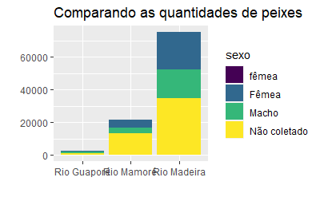

```r
dados_peixes %>%
  count(bacia, sexo) %>%
  ggplot(aes(x = fct_reorder(bacia, n), y = n, fill = sexo)) +
  geom_col() +
  scale_fill_viridis_d() +
  labs(
    title = "Comparando as quantidades de peixes",
    x = "",
    y = ""
)
```

**Questão 04.** Faça um gráfico de pontos relacionando o peso (em kilogramas) e o comprimento (em metros), destacando a curva que melhor se adequa aos pontos, colorindo segundo a variável `ordem`. Depois, facete-o por `bacia`. Para ajudar, complete adequadamente o código abaixo (considere a variável `dados_peixes`, o conjunto de dados em questão), substituindo o símbolo “❓❓” pela variável conveniente.

```r
dados_peixes %>%
  select(ordem, peso_g, cp_cm, bacia) %>%
  ggplot() +
  aes(x= peso_g/1000, y = cp_cm/100) +
  geom_point(aes(color = ordem), alpha = 0.5) +
  facet_grid(bacia~.) +
  geom_smooth()
```

[output not shown]

1. A curva que se adapta aos pontos é (praticamente) a mesma em cada bacia?

*Resposta: Não, pois a curva é praticamente a mesma, porém tem a diferença do tamanho da curva em cada bacia.*

2. Qual a sua interpretação para esse fato (dica: pesquise sobre a curva de “crescimento logístico” aplicada ao crescimento de população - no caso, de peixes)?

*Resposta: Com o excesso de peixes pode causa descontrole e falta de oxigenio, além disso no rio madeira a superpopulação de pirarucu está prejudicando outras espécies de peixes, pois com o desequilibrio o pirarucu está devorando outros peixes, isso e uma das causas da superpopulação dos peixes.*